# Color Blur Object Project

Geoff Boynton and Ione Fine

9/21/26

Knit this document to generate an HTML file showing the statistics in the paper.

Trial-level responses were analyzed using a signal-detection-theoretic (SDT) generalized linear mixed-effects model, rather than modeling raw accuracy directly. We fit the SDT model directly to the trial-level yes/no responses (DeCarlo, 1998; Rouder & Lu, 2005), using the reconstructed stimulus identity (“signal present” vs. “signal absent”) as a predictor.

For each blur experiment, diopter was treated as a categorical factor, allowing sensitivity to vary freely across the tested blur levels rather than imposing a linear trend. A mixed-effects probit regression of the form `resp ~ signal * diopter * color + (1 | subject)` was fit by maximum likelihood in `lme4`. On the probit scale, the signal-present minus signal-absent contrast is model-based d’.

Interactions of `signal` with `diopter` and/or `color` therefore test whether sensitivity changes with blur differs between color and grayscale images. Terms not involving `signal` describe changes in response criterion. The subject random intercept allows criterion to vary across participants. A subject-specific random slope for `signal` was initially considered, but the random-effects structure was simplified after it produced a singular fit. Statistical significance of the fixed effects was evaluated using Type II Wald chi-square tests (`car::Anova`).

Note, the names for the experiments differ between the data and the paper:

```
        Paper              Data
    Experiment 1           Exp3
    Experiment 2           Exp1
    Experiment 3           Exp2
```

## Experiment 1:

12 participants

“Mean accuracy was 85.6 percent for color images and 85.9 percent for grayscale images. The SDT mixed-effects model revealed no significant difference in sensitivity between color and grayscale images ($\chi^2$(1) = 0.04, p = 0.8473). Mean response times were 1.99 seconds for color images and 2.01 seconds for grayscale images. A logistic mixed-effects model revealed no significant effect of color on RTs ($F$(1,2099) = 0.3684, p = 0.544).”

## Image Selection

“To ensure reliable recognition in the blur experiments, we excluded any images for which fewer than 75 percent of participants responded correctly across both the color and gray conditions of Experiment 1. This eliminated 27 of the 177 images (~15) percent with 150 images remaining.”

## Exp1

### SDT generalized linear mixed-effects model

Statistical inference was based on a binomial generalized linear mixed-effects model fit to trial-level responses using a probit link. Sensitivity varied significantly across blur levels, as indicated by the `signal × diopter` interaction, χ²(8) = 223.72, *p* < .0001. Inspection of the model-based estimates showed that d’ declined overall as blur increased. Sensitivity also differed significantly between color and grayscale images, `signal × color`, χ²(1) = 10.37, *p* = 0.0013, with greater sensitivity for color than for grayscale images. Critically, the `signal × diopter × color` interaction was significant, χ²(8) = 19.18, *p* = 0.0139, indicating that the difference in d’ between color and grayscale images depended on the level of blur. The grouped-blur post-hoc comparisons below were used to localize this interaction. Terms not involving `signal` concern response criterion rather than sensitivity and are reported in the full Wald table below.

Exp1: Type II Wald chi-square tests for the trial-level SDT model

| Effect | Chisq | Df | Pr(>Chisq) |
| --- | --- | --- | --- |
| signal | 421.3124 | 1 | 0.0000 |
| diopter | 63.9793 | 8 | 0.0000 |
| color | 0.8595 | 1 | 0.3539 |
| signal:diopter | 223.7205 | 8 | 0.0000 |
| signal:color | 10.3736 | 1 | 0.0013 |
| diopter:color | 7.3026 | 8 | 0.5044 |
| signal:diopter:color | 19.1826 | 8 | 0.0139 |

### Model-based sensitivity across blur levels

The figure shows model-based d’ at each tested blur level for color and grayscale images. Error bars indicate +/- 1 standard error.

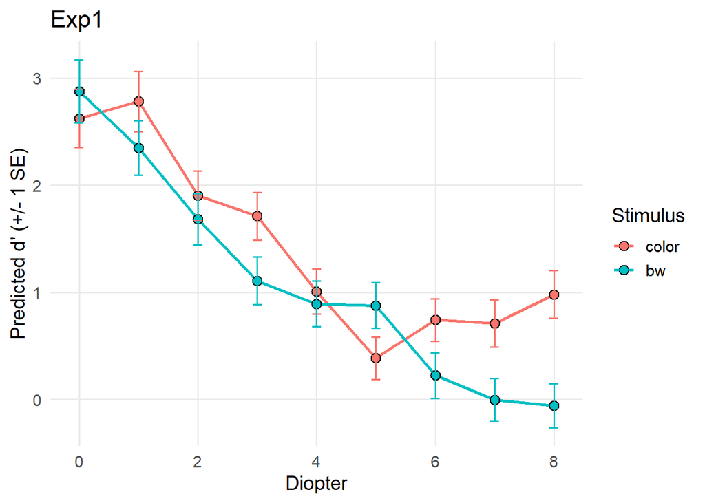

### Post-hoc color comparisons within grouped blur levels

| signal_revpairwise | color_pairwise | blur_group | estimate | SE | df | asymp.LCL | asymp.UCL | z.ratio | p.value |
| --- | --- | --- | --- | --- | --- | --- | --- | --- | --- |
| present - absent | color - bw | 0-2 | 0.132 | 0.208 | Inf | -0.276 | 0.539 | 0.633 | 0.527 |
| present - absent | color - bw | 3-5 | 0.118 | 0.169 | Inf | -0.214 | 0.450 | 0.697 | 0.486 |
| present - absent | color - bw | 6-8 | 0.755 | 0.170 | Inf | 0.421 | 1.089 | 4.428 | 0.000 |

## Exp2

### SDT generalized linear mixed-effects model

Statistical inference was based on a binomial generalized linear mixed-effects model fit to trial-level responses using a probit link. Sensitivity varied significantly across blur levels, as indicated by the `signal × diopter` interaction, χ²(8) = 93.46, *p* < .0001. Inspection of the model-based estimates showed that d’ declined overall as blur increased. Sensitivity also differed significantly between color and grayscale images, `signal × color`, χ²(1) = 7.14, *p* = 0.0075, with greater sensitivity for color than for grayscale images. The `signal × diopter × color` interaction was not significant, χ²(8) = 7.81, *p* = 0.4524, providing no significant evidence that the color difference in d’ changed across blur levels. Terms not involving `signal` concern response criterion rather than sensitivity and are reported in the full Wald table below.

Exp2: Type II Wald chi-square tests for the trial-level SDT model

| Effect | Chisq | Df | Pr(>Chisq) |
| --- | --- | --- | --- |
| signal | 195.3072 | 1 | 0.0000 |
| diopter | 36.5974 | 8 | 0.0000 |
| color | 6.5159 | 1 | 0.0107 |
| signal:diopter | 93.4582 | 8 | 0.0000 |
| signal:color | 7.1401 | 1 | 0.0075 |
| diopter:color | 5.7329 | 8 | 0.6771 |
| signal:diopter:color | 7.8088 | 8 | 0.4524 |

### Model-based sensitivity across blur levels

The figure shows model-based d’ at each tested blur level for color and grayscale images. Error bars indicate +/- 1 standard error.

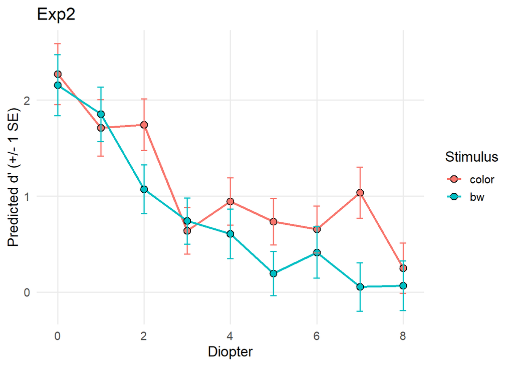

### Post-hoc color comparisons within grouped blur levels

| signal_revpairwise | color_pairwise | blur_group | estimate | SE | df | asymp.LCL | asymp.UCL | z.ratio | p.value |
| --- | --- | --- | --- | --- | --- | --- | --- | --- | --- |
| present - absent | color - bw | 0-2 | 0.285 | 0.229 | Inf | -0.165 | 0.734 | 1.241 | 0.214 |
| present - absent | color - bw | 3-5 | 0.260 | 0.197 | Inf | -0.126 | 0.646 | 1.321 | 0.186 |
| present - absent | color - bw | 6-8 | 0.451 | 0.209 | Inf | 0.042 | 0.860 | 2.159 | 0.031 |

```r
exp3_data <- subset(all_data,exp=="Exp3")
subList <- unique(exp3_data$subId)

for (i in 1:length(subList)) {
  exp3_sub <- subset(exp3_data, pc>0 &  subId == subList[i])
  cat(setdiff(unique(exp3_data$idnum),exp3_sub$idnum),'\n')
}
```

```
## 100
## 46
## 114
## 131
## 79
## 180
## 156
## 135
## 188
## 83
## 110
## 104
```